# Лабораторная работа 5. Основы анализа данных NumPy и Matplotlib.

# Часть 1. NumPy

При решении научных задач с помощью численных методов зачастую приходится иметь дело с большими массивами данных в виде массивов и матриц. Стандартные средства Python (например, использование списков для хранения данных и прямой перебор элементов с помощью циклов) плохо подходят для таких задач, так как будут работать крайне медленно, в отличие от программ на компилируемых языках (Fortran, С). Пакет NumPy (http://www.numpy.org/) — это основной пакет, исполь¬зуемый в научных вычислениях в Python. NumPy предназначен для эф¬фективной работы с многомерными массивами, в том числе для эффек¬тивного применения математических операций к массивам и матрицам и их модификации без прямого перечисления элементов массивов. Поми¬мо этого NumPy обладает и другими возможностями — линейная алгеб¬ра, удобный ввод/вывод в файлы, моделирование случайных величин, быстрое преобразование Фурье, объединение программ на Fortran и С и другое (подробнее см. оф. сайт), поэтому важно изучить возможно¬сти данной библиотеки как можно лучше.

1. Внимательно изучите следующий урок по NumPy: http://scipy.github.io/old-wiki/pages/Tentative_NumPy_Tutorial.
2. Изучите официальное руководство пользователя https://docs.scipy.org/doc/numpy/user/.
3. Внимательно изучите Reference Guide (полное описание всех функ¬ций) https://docs.scipy.org/doc/numpy/reference/, именно в нем перечислены все возможности NumPy, этой ссылкой придется регу¬лярно пользоваться.

Выполните следующие задания (их много, но каждое занимает одну или несколько строк) средствами NumPy (и без использования циклов!)

Импортируйте пакет numpy под именем nр

```python
import numpy as np
```

Создайте вектор из 10 элементов, заполненный 0, пятый эле-мент которого равен 1.

```python
somevector = np.full(10,0)
#или np.zeros
somevector[4]=1
print(somevector)
```

```
[0 0 0 0 1 0 0 0 0 0]
```

Создайте матрицу 3 на 3 со значениями от 0 до 8.

```python
#somematrix = np.random.randint(0, 9, (3, 3))
somematrix = np.arange(0,9).reshape(3,3)
print(somematrix)
```

```
[[0 1 2]
 [3 4 5]
 [6 7 8]]
```

Найдите индексы ненулевых элементов вектора [1,2,0,0,4,0].

```python
vector = np.argwhere([1,2,0,0,4,0])
print(vector)
```

```
[[0]
 [1]
 [4]]
```

Объявите единичную матрицу размером 3 на 3.

```python
print(np.eye(3))
```

```
[[1. 0. 0.]
 [0. 1. 0.]
 [0. 0. 1.]]
```

Создайте массив 10x10x10 из случайных чисел.

```python
print(np.random.randint(0, 10, (10,10,10)) )
```

```
[[[2 3 7 2 7 7 5 9 2 7]
  [9 0 8 7 0 6 2 4 6 7]
  [7 0 1 8 7 4 8 6 5 8]
  [0 2 2 2 6 7 0 5 5 3]
  [5 1 4 8 8 0 7 9 7 0]
  [0 1 9 8 3 5 6 1 6 7]
  [7 1 1 9 5 8 5 4 7 9]
  [2 6 9 7 3 4 3 7 2 9]
  [8 9 7 4 0 1 8 8 6 4]
  [7 4 3 0 5 0 0 1 7 6]]

 [[8 4 8 2 9 3 8 7 7 3]
  [6 3 3 2 2 5 5 6 9 6]
  [4 7 3 4 8 6 9 1 5 3]
  [0 6 2 3 1 6 8 6 4 2]
```

[output cut: 94 more lines]

Создайте матрицу 8 на 8, заполненную 0 и 1 в шахматном порядке.

```python
print(np.tile(np.array([[0,1],[1,0]]),(4,4)))
```

```
[[0 1 0 1 0 1 0 1]
 [1 0 1 0 1 0 1 0]
 [0 1 0 1 0 1 0 1]
 [1 0 1 0 1 0 1 0]
 [0 1 0 1 0 1 0 1]
 [1 0 1 0 1 0 1 0]
 [0 1 0 1 0 1 0 1]
 [1 0 1 0 1 0 1 0]]
```

Найдите произведение матриц 5x3 на 3x2 (см. линейную ал-гебру) .

```python
a = np.ones((5,3))
b = np.full((3,2),2)
print(np.dot(a,b))
```

```
[[6. 6.]
 [6. 6.]
 [6. 6.]
 [6. 6.]
 [6. 6.]]
```

Создайте матрицу, в каждом ряду которой стоят числа от 0 до 8 (используйте сложение матрицы с вектором).

```python
print(np.zeros((9,9)) + np.arange(0,9))
```

```
[[0. 1. 2. 3. 4. 5. 6. 7. 8.]
 [0. 1. 2. 3. 4. 5. 6. 7. 8.]
 [0. 1. 2. 3. 4. 5. 6. 7. 8.]
 [0. 1. 2. 3. 4. 5. 6. 7. 8.]
 [0. 1. 2. 3. 4. 5. 6. 7. 8.]
 [0. 1. 2. 3. 4. 5. 6. 7. 8.]
 [0. 1. 2. 3. 4. 5. 6. 7. 8.]
 [0. 1. 2. 3. 4. 5. 6. 7. 8.]
 [0. 1. 2. 3. 4. 5. 6. 7. 8.]]
```

Создайте вектор длины 1000. Найдите среднее (арифметиче¬ское) значение из этих элементов.

```python
print(np.full(1000,2).mean())
```

```
2.0
```

## Часть 2. Matplotlib

Matplotlib (http://matplotlib.org/index.html) — это библиотека для создания графиков в Python. Matplotlib позволяет строить графики любой сложности типографского качества, которые можно вставить в статью. Подробнее о возможностях см. http://matplotlib.org/users/ intro.html. Matplotlib — большой и сложный инструмент, но на прак¬тике в научных вычислениях часто пользуются частью библиотеки matplotlib .pyplot, которая имитирует построение графиков в стиле MATLAB. В качестве до¬статочно полного введения можно прочитать http://matplotlib.org/users/index.html.

На практике бывает очень трудно помнить все возможности Matplotlib, поэтому часто используют галереи готовых примеров, а потом модифи-цируют их под свои нужды. Примеры таких подборок можно найти по следующим ссылкам: • http://matplotlib.org/gallery.html • http://matplotlib.org/examples/index.html • http://wiki.scipy.org/Cookbook/Matplotlib/

Еще материалы.

1. Введение http://matplotlib.org/users/pyplot_tutorial.html
2. Введение 2 http://www.loria.fr/~rougier/teaching/matplotlib/. Изучите, как создавать графики разных типов http://www.loria. fr/~rougier/teaching/matplotlib/#other-types-of-plots.
3. Использование текста в подписях и т.д. http://matplotlib.org/ users/text_intro.html.
4. Использование математического текста http: //matplotlib. org/users/ mathtext.html.
5. Создание легенды http://matplotlib.org/users/legend_guide.html.
6. Интерактивное использование Matplotlib http: //matplotlib. org/ users/shell .html (этот пример можно использовать не только в командной строке, но и в коде для наблюдения за изменением гра¬фиков в ходе выполнения программы).

Постройте поточечный график функции. Сгенерируйте два массива для этого. Один со значениями по возрастанию (для X), второй со случайными значениями (для Y).

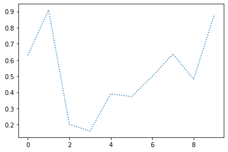

```python
import matplotlib.pyplot as pl

x = np.arange(0,10)
y = np.random.random(10)
print(pl.plot(x,y,':'))
```

Выберите тригонометрическую функцию $T(x)$, выберите полином $P(x)$. Постройте график функции $T(x)P(x)$.

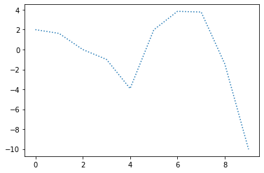

```python
def P(x):
    return x^2
x = np.arange(0,10)
y = np.cos(x)*P(x)
print(pl.plot(x,y,':'))
```

К графику добавьте: обозначение оси абсцисс, обозначение оси ординат, название графика, вставка легенды (текста в label).

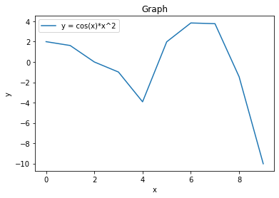

```python
pl.title('Graph')
pl.xlabel('x')
pl.ylabel('y')
pl.plot(x,y,'-',label = 'y = cos(x)*x^2')
pl.legend(loc='best')
```

Измените цвет графика на Ваш любимый.

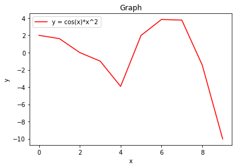

```python
pl.title('Graph')
pl.xlabel('x')
pl.ylabel('y')
pl.plot(x,y,'-',label = 'y = cos(x)*x^2', color = 'red')
pl.legend(loc='best')
```

Постройте несколько квивых. Первая - цвет красный, сплошная, вторая - цвет синий, штрих-пунктир.

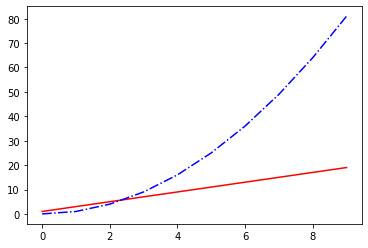

```python
pl.plot(x, 2*x + 1, '-', color = 'red')
pl.plot(x, x**2, '-.', color = 'blue')
```

Постройте теже графики, только для первого добавьте маркеры из красных треугольников, для второго синие круглые маркеры.

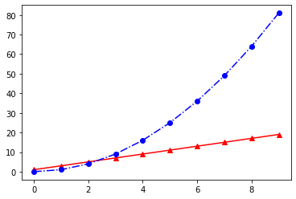

```python
pl.plot(x, 2*x + 1, '-', color = 'red',marker = '^')
pl.plot(x, x**2, '-.', color = 'blue', marker = 'o')
```

# Часть 3. OpenCV

```python
import cv2
flags = [i for i in dir(cv2) if i.startswith('COLOR_')]
#len(flags)
flags[41]
```

```
'COLOR_BGR2HLS_FULL'
```

Прочитайте картинку используя opencv

[figure not shown]

```python
img = cv2.imread('pth3.jpg',cv2.COLOR_BGR2RGB)
pl.imshow(img)
pl.show()
#что-то с цветом
```

Сделайте ее черно-белой

[figure not shown]

```python
black_img = cv2.cvtColor(img,cv2.COLOR_BGR2GRAY)
pl.imshow(black_img)
```

Измените размер на 300x300

[figure not shown]

```python
size_img = cv2.resize(img, (300, 300))
pl.imshow(size_img)
```

Разбейте ее на 2 картинки. Сохраните.

```python
height, width = img.shape[:2]
up = img[:height//2, :width]
down = img[height//2:, :width]
cv2.imwrite('up.png', up)
cv2.imwrite('down.png', down)
```

```
True
```

Прочитайте 2 картинки и склейте.

[figure not shown]

```python
up_img = cv2.imread('up.png')
down_img = cv2.imread('down.png')
result = np.concatenate((up_img, down_img), axis=0)
pl.imshow(result)
```